# The Curse of Dimensionality

Pietro Franceschi | pietro.franceschi@fmach.it

## Intro

In the lecture we said that metabolomics data matrices are *fat*: many more variables than samples. Intuitively, measuring more should be better … but is it?

In this demo we look at what happens to the “geometry” of our samples when the number of measured variables grows. The tool is the **distance matrix**: the distance between every pair of samples. Many of the methods we will use in the course (clustering, PCA, k-nearest neighbours, …) are based, more or less explicitly, on distances.

## A two group experiment

```r
n_per_group <- 10
delta <- 2
nvars <- 10^(0:5)
```

We have two groups of 10 samples each (`A` and `B`), drawn from two populations with the same standard deviation (1) but different means: the difference is 2 standard deviations, a large effect!

Only **one** variable (the “biomarker”) carries this difference. All the other variables we measure are just noise: same distribution in the two groups. This is a realistic picture of an untargeted metabolomics experiment, where most of the features have nothing to do with our scientific question.

We simulate 6 scenarios, measuring 1, 10, 100, 1,000, 10,000, 100,000 variables

```r
group <- rep(c("A", "B"), each = n_per_group)

## first column: the biomarker; the remaining nvar - 1 columns: noise
make_dm <- function(nvar) {
  biomarker <- rnorm(2 * n_per_group, mean = ifelse(group == "B", delta, 0))
  noise <- matrix(rnorm(2 * n_per_group * (nvar - 1)), nrow = 2 * n_per_group)
  cbind(biomarker, noise)
}

curse <- tibble(nvar = nvars) |>
  mutate(DM = map(nvar, make_dm))

curse
```

```
## # A tibble: 6 × 2
##     nvar DM
##    <dbl> <list>
## 1      1 <dbl [20 × 1]>
## 2     10 <dbl [20 × 10]>
## 3    100 <dbl [20 × 100]>
## 4   1000 <dbl [20 × 1,000]>
## 5  10000 <dbl [20 × 10,000]>
## 6 100000 <dbl [20 × 100,000]>
```

## Distance matrices

For each data matrix we calculate the euclidean distance between all pairs of samples

```r
curse <- curse |>
  mutate(D = map(DM, \(m) as.matrix(dist(m))))
```

The distances get larger and larger as we add variables, so to compare the scenarios we divide each matrix by its largest distance. In the plot, the samples are ordered by group: the first 10 belong to `A`, the last 10 to `B`

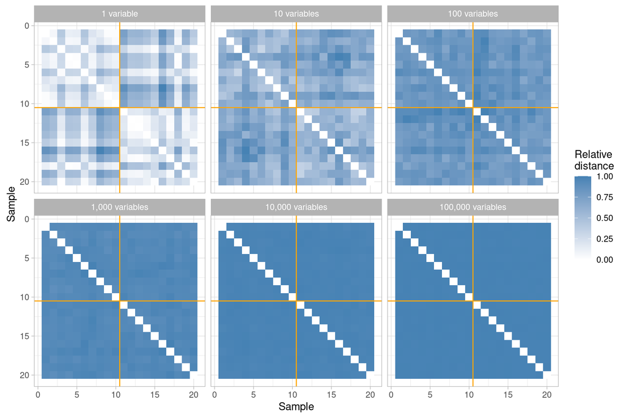

```r
## from matrix to long table: one row per pair of samples
to_long <- function(d) {
  tibble(s1 = as.vector(row(d)), s2 = as.vector(col(d)), dist = as.vector(d / max(d)))
}

curse |>
  mutate(long = map(D, to_long),
         nvar = paste(scales::label_comma()(nvar), if_else(nvar == 1, "variable", "variables")),
         nvar = fct_inorder(nvar)) |>
  dplyr::select(nvar, long) |>
  unnest(long) |>
  ggplot(aes(x = s1, y = s2, fill = dist)) +
  geom_tile() +
  geom_hline(yintercept = n_per_group + 0.5, colour = "orange") +
  geom_vline(xintercept = n_per_group + 0.5, colour = "orange") +
  scale_fill_gradient(low = "white", high = "steelblue", limits = c(0, 1)) +
  scale_y_reverse() +
  facet_wrap(vars(nvar)) +
  coord_equal() +
  labs(x = "Sample", y = "Sample", fill = "Relative\ndistance") +
  theme_light()
```

- With **one** variable the two groups are clearly visible: small distances (light) inside the groups, large distances (dark) between them
- Adding noise variables, the block structure fades away … with 1,000 variables or more it is gone
- With many variables the matrix becomes almost uniform: **all samples are at about the same distance from each other**

## Putting numbers on it

One number summarizes what we see: the **between/within** ratio, the average distance between samples of different groups divided by the average distance between samples of the same group. If the groups are visible, this is larger than 1; if there are no groups, it is 1

```r
between_within <- function(d) {
  ut <- upper.tri(d)
  same <- outer(group, group, "==")
  mean(d[ut & !same]) / mean(d[ut & same])
}

curse <- curse |>
  mutate(bw = map_dbl(D, between_within))

curse |> dplyr::select(nvar, bw)
```

```
## # A tibble: 6 × 2
##     nvar    bw
##    <dbl> <dbl>
## 1      1  1.94
## 2     10  1.18
## 3    100  1.01
## 4   1000  1.00
## 5  10000  1.00
## 6 100000  1.00
```

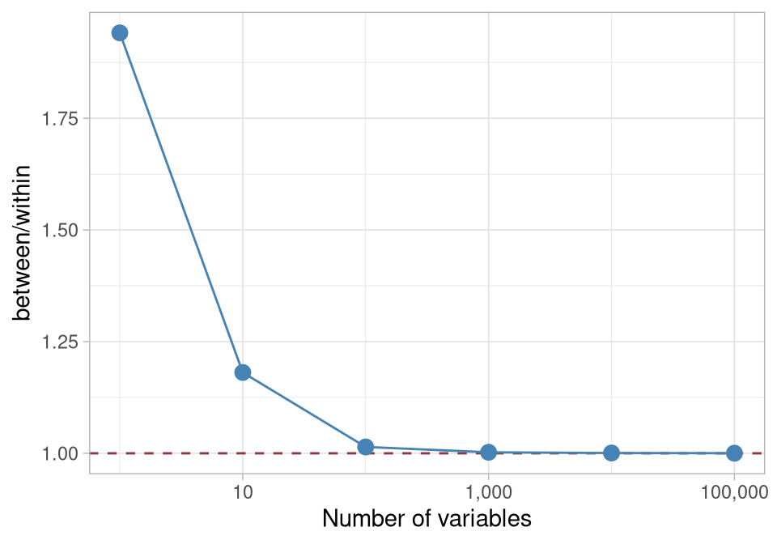

```r
curse |>
  ggplot(aes(x = nvar, y = bw)) +
  geom_hline(yintercept = 1, colour = "#8B3A3A", linetype = "dashed") +
  geom_line(colour = "steelblue") +
  geom_point(colour = "steelblue", size = 3) +
  scale_x_log10(labels = scales::label_comma()) +
  labs(x = "Number of variables", y = "between/within") +
  theme_light()
```

The ratio goes from 1.94 to 1: the groups disappear (the dashed line is the “no groups” value).

> **The biomarker is still there, in the first column of every matrix! But the distances are dominated by the noise of all the other variables. This is the curse of dimensionality: in a high dimensional space the data are sparse, and every sample is far from all the others.**

## Is it the number of variables?

Not really … it is the number of **useless** variables. Let’s repeat the simulation where *all* the variables are different between the two groups

```r
make_dm_all <- function(nvar) {
  matrix(rnorm(2 * n_per_group * nvar, mean = ifelse(group == "B", delta, 0)),
         nrow = 2 * n_per_group)
}

curse_all <- tibble(nvar = nvars) |>
  mutate(D = map(nvar, \(p) as.matrix(dist(make_dm_all(p)))),
         bw = map_dbl(D, between_within))

curse_all |> dplyr::select(nvar, bw)
```

```
## # A tibble: 6 × 2
##     nvar    bw
##    <dbl> <dbl>
## 1      1  2.65
## 2     10  1.71
## 3    100  1.78
## 4   1000  1.73
## 5  10000  1.72
## 6 100000  1.73
```

> **In metabolomics we measure thousands of features, but only a handful of them are related to our question. More variables means more noise, not more information.**

This is why with fat data matrices we need to be careful with distance based methods and with any approach that “looks at everything at once” … and, as we will see in the practical, it is also why random noise can produce convincing patterns.

## Something for you!

1. Play around and try to understand what I did
2. Repeat the simulation with 10 biomarkers instead of 1 (the other variables are still noise). How many variables can you measure before the groups disappear?

## A possible solution

We add a parameter with the number of biomarkers: the first `n_bio` columns are different between the two groups

```r
make_dm_bio <- function(nvar, n_bio) {
  n_bio <- min(n_bio, nvar)
  bio <- matrix(rnorm(2 * n_per_group * n_bio, mean = ifelse(group == "B", delta, 0)),
                nrow = 2 * n_per_group)
  noise <- matrix(rnorm(2 * n_per_group * (nvar - n_bio)), nrow = 2 * n_per_group)
  cbind(bio, noise)
}

bio10 <- tibble(nvar = nvars) |>
  mutate(D = map(nvar, \(p) as.matrix(dist(make_dm_bio(p, n_bio = 10)))),
         bw = map_dbl(D, between_within))

bio10 |> dplyr::select(nvar, bw)
```

```
## # A tibble: 6 × 2
##     nvar    bw
##    <dbl> <dbl>
## 1      1  2.93
## 2     10  1.81
## 3    100  1.08
## 4   1000  1.01
## 5  10000  1.00
## 6 100000  1.00
```

With 10 biomarkers the groups survive longer (between/within 1.81 with 10 variables, against 1.18 with a single biomarker), but in the end the noise wins: the ratio drops to 1. More good variables delay the curse, they do not remove it.